# Applying PCA, BCT and Imposters using word features

# Introduction

In this notebook we will apply Principal Component Analysis, Bootstrap Consensus Tree and the `imposters()` method to make the results a little bit more interpretable. This is a supplement material to the main analysis which will be conducted with character 4-grams and character 5-grams.

```r
# import the neccessary libraries
# if a library is not installed run the following command: `install.packages(package to install)`
library(stylo)
# library(gplots)
# library(pheatmap)
```

# Setting the working directory

```r
setwd("../../analysis/word_features/")
getwd()
```

```
[1] "/Users/paschalis/Documents/MA_DH/Thesis/seneca_stylometry/analysis/word_features"
```

# Preparation of the data

## Importing the corpus and tokenisation

In this step we import the corpus that we are going to use and consequently we tokenize it. The tokenisation follows the rules of the parameter `Latin.corr`. This is done because a lot of texts do not distinguish “u/v” and by setting this parameter to `Latin.corr` we take care of this variation in the letters. Moreover, we change uppercase letters to lowercase.

We should clarify that since applying PCA and BCT to a dataset with a big number of authors and works might cause some overlapping and might make the interpretation of the plots impossible; we decided to shrink the dataset to authors that lived very close to Seneca’s the Younger time, such as Lucan. To test Ferri’s hypothesis that *Silvae* by Statius might work as a terminus ante quem for *Octavia*, we have also included Statius works. Due to their small size, *Satires* by Persius are excluded from the dataset; this will allow us to extract some samples from the texts to balance very large texts with “normal” size texts.

```r
raw.corpus <- load.corpus(files = "all", corpus.dir = "../verse_corpus_pca_bct/",
                          encoding = "UTF-8")

tokenized.corpus <- txt.to.words.ext(raw.corpus, corpus.lang = "Latin.corr",
                                     preserve.case = FALSE)

# make samples
sliced.corpus <- make.samples(tokenized.corpus,
                              sampling = "random.sampling",
                              number.of.samples = 2,
                              sample.size = 3000)
```

```
luc_phars_1.txt
    - text length (in words): 4375
    - nr. of random samples: 2
    - sample length: 3000
luc_phars_10.txt
    - text length (in words): 3506
    - nr. of random samples: 2
    - sample length: 3000
luc_phars_2.txt
    - text length (in words): 4643
    - nr. of random samples: 2
    - sample length: 3000
luc_phars_3.txt
    - text length (in words): 4763
    - nr. of random samples: 2
    - sample length: 3000
luc_phars_4.txt
    - text length (in words): 5153
    - nr. of random samples: 2
    - sample length: 3000
luc_phars_5.txt
    - text length (in words): 5181
    - nr. of random samples: 2
    - sample length: 3000
luc_phars_6.txt
    - text length (in words): 5163
    - nr. of random samples: 2
    - sample length: 3000
luc_phars_7.txt
    - text length (in words): 5589
    - nr. of random samples: 2
    - sample length: 3000
luc_phars_8.txt
    - text length (in words): 5618
    - nr. of random samples: 2
    - sample length: 3000
luc_phars_9.txt
    - text length (in words): 7074
    - nr. of random samples: 2
    - sample length: 3000
```

[output cut: 97 more lines]

```
    - text length (in words): 6002
    - nr. of random samples: 2
    - sample length: 3000
stat_theb_7.txt
    - text length (in words): 5273
    - nr. of random samples: 2
    - sample length: 3000
stat_theb_8.txt
    - text length (in words): 4945
    - nr. of random samples: 2
    - sample length: 3000
stat_theb_9.txt
    - text length (in words): 5829
    - nr. of random samples: 2
    - sample length: 3000
```

```r
set.seed(76) # seed for reproducibility

help("make.samples")
```

## Remove the pronouns

It was decided to remove the pronouns, since some pronouns are connected to the genre of the text.

```r
corpus.no.pronouns <- delete.stop.words(sliced.corpus,
                                        stop.words = stylo.pronouns(corpus.lang = "Latin.corr"))
```

## Extracting the features

The final step before proceeding to the method per se is to extract the features that we want to use and add them to a table with frequencies. In our case, we want to extract word 1grams (i.e., simple words (aka tokens)).

```r
corpus.w.grams <- txt.to.features(corpus.no.pronouns,
                                  ngram.size = 1,
                                  features = "w")

freq.features.word.grams <- make.frequency.list(corpus.w.grams,
                                                head = 3000)

freqs.word.grams <- make.table.of.frequencies(corpus.w.grams,
                                              features = freq.features.word.grams,
                                              relative = T)
```

```
processing  76  text samples
.......
combining frequencies into a table...
```

# Methods

## Principal Component Analysis

We will run two separate experiments with PCA; one will be using a correlation plot to visualize the results and on will be using a covariance plot.

```
using current directory...
Warning: chosen stop words were not found in the dataset;
  please check the language, lower/uppercase issues, etc.


culling @ 0 available features (words) 3000
MFW used:
100
Processing metadata...


Assigning plot colors according to file names...
```

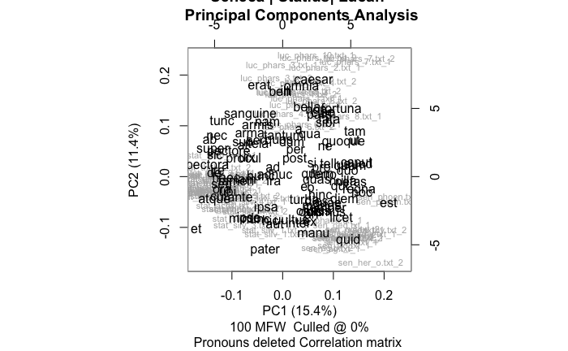

```r
# PCA 100 | no culling to obtain a sufficient number of features
results_pca_4grams_cor = stylo(frequencies = freqs.word.grams,
                               analysis.type = "PCR",
                               mfw.min = 100, mfw.max = 100, #look at this small number of words because of the flavour
                               distance.measure = "eder",
                               custom.graph.title = "Seneca | Statius| Lucan",
                               write.png.file = T,
                               pca.visual.flavour = "loadings", # too many words if set to 1000 or more, graph impossible to read
                               gui = T)
```

```r
# same visualisation without the words, only with the filename
# include a bigger range of MFW to show the robustness of the results
# PCA 100-1500 MFW | no culling to obtain a sufficient number of features
results_pca_4grams_cor = stylo(frequencies = freqs.word.grams,
                               analysis.type = "PCR",
                               mfw.min = 100, mfw.max = 1500, increment = 100,
                               distance.measure = "eder",
                               custom.graph.title = "Seneca | Statius| Lucan",
                               write.png.file = T,
                               pca.visual.flavour = "classic",
                               gui = T)
```

```r
# apply the same technique but this time using a covariance plot instead of a correlation
# first one will be technical, the second one will be without the words
# using a broader range of words to test the robustness of the results
results_pca_4grams_cov_1 = stylo(frequencies = freqs.word.grams,
                                 analysis.type = "PCR",
                                 mfw.min = 100, mfw.max = 100,
                                 distance.measure = "eder",
                                 custom.graph.title = "Seneca | Statius| Lucan",
                                 write.png.file = T,
                                 pca.visual.flavour = "loadings",
                                 gui = T)
```

[output not shown]

```r
# same visualization without the words, only with the filename
# include a bigger range of MFW to show the robustness of the results
# PCA 100-1500 MFW | no culling to obtain a sufficient number of features
results_pca_4grams_cov_2 = stylo(frequencies = freqs.word.grams,
                                 analysis.type = "PCR",
                                 mfw.min = 100, mfw.max = 1500, increment = 100,
                                 distance.measure = "eder",
                                 custom.graph.title = "Seneca | Statius| Lucan",
                                 write.png.file = T,
                                 pca.visual.flavour = "classic",
                                 gui = T)
```

[output not shown]

# Apply BCT

For this method, we won’t use the the sliced corpus (i.e., the corpus with the random samples of the texts) because the plot get very populated, it looks like a moving fidget spinner, and it very hard to read.

```r
corpus.no.pronouns <- delete.stop.words(tokenized.corpus, # if you want the sliced corpus change `tokenize.corpus` to `sliced.corpus`
                                        stop.words = stylo.pronouns(corpus.lang = "Latin.corr"))

corpus.w.grams <- txt.to.features(corpus.no.pronouns,
                                  ngram.size = 1,
                                  features = "w")

freq.features.word.grams <- make.frequency.list(corpus.w.grams,
                                                head = 3000)

freqs.word.grams <- make.table.of.frequencies(corpus.w.grams,
                                              features = freq.features.word.grams,
                                              relative = T)
```

```
processing  38  text samples
...
combining frequencies into a table...
```

[output not shown]

[output cut: 44 more lines]

```


Assigning plot colors according to file names...

1400
Processing metadata...


Assigning plot colors according to file names...

1500
Processing metadata...


Assigning plot colors according to file names...
```

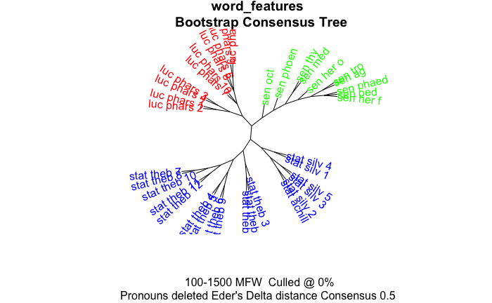

```r
bct.results.words = stylo(frequencies = freqs.word.grams,
                          distance.measure = "eder",
                          analysis.type = "BCT",
                          mfw.min = 100, mfw.max = 1500, increment = 100,
                          consensus.strength = 0.5,
                          write.png.file = T,
                          gui = T)
```